# SELECTION SIGNATURES - POPULATION GENETICS

BIO - 641 | Prof. Dr. Kaio Olimpio

Caio Cruz, Italo Sardinha, MUhammad e Vitor Bialetzki Cristiano

19/10/2026

# INTRODUCTION

Plant domestication involves evolutionary processes like genetic drift, inbreeding, natural selection, and active selection, which together have shaped diverse livestock breeds adapted to various environments. While natural selection improves survival and reproductive fitness, artificial selection is split into ancient unconscious selection and deliberate, goal oriented methodical selection. These selection strategies drive changes in specific genomic regions controlling traits such as morphology, production performance, behavior, adaptation, and disease resistance. The unique genetic footprints left behind in these regions are called selection signatures. When a new beneficial mutation rapidly reaches fixation, it reduces genetic variability in neighboring neutral sites, a phenomenon known as a selective sweep, hitchhiking effect, or genetic draft. Studying genomic variation in Zea mays L. helps us understand the genetic architecture of complex traits, population demography, and the evolutionary mechanisms driven by selection. This analysis uses genotyping data from the NCBI GEO repository under accession GSE50558, which includes 2,233 doubled haploid lines derived from 24 biparental populations alongside their 23 parents, genotyped using the Illumina MaizeSNP50 BeadChip. The dataset covers two half sib germplasm panels: the Dent panel (CFD prefix), containing 1,005 lines, and the Flint panel (CFF prefix), containing 1,262 lines. The analytical approach follows two main steps. First, we present a descriptive analysis of the population structure. Second, we apply statistical tests to detect selection signatures across the genome.

## POPULATION STRUCTURE

Understanding population structure and genetic relationships among individuals is an essential first step in population genetics. Before identifying selection signatures, it is important to account for underlying genetic divergence, family structure, and inbreeding. Uncontrolled population stratification can lead to false-positive signals and obscure genuine evidence of selection.

In this section, we investigate the genomic diversity of a maize dataset obtained from NCBI GEO (accession GSE50558), comprising 23 parental lines and two half-sib panels: Dent (CFD prefix) and Flint (CFF prefix).

### Analytical Workflow

Our population structure analysis follows three main steps:

#### SNP Recoding and Genomic Relationship Matrix ((G)-matrix)

SNP genotypes were recoded as additive allele dosages: 0 for homozygous reference genotypes, 1 for heterozygous genotypes, and 2 for homozygous alternate genotypes. onsThe AGHmatrix package was used to construct a genomic relatihip matrix according to VanRaden’s method, quantifying genomic relationships among individuals. The resulting matrix was visualized as a heatmap to explore patterns of genetic relatedness.

####Hierarchical Clustering and Dendrograms

Hierarchical clustering was performed using genetic distances derived from the (G)-matrix. Both linear and circular dendrograms were generated to visualize relationships among individuals and assess the clustering patterns of the Dent, Flint, and parental lines.

#### Principal Component Analysis (2D and 3D PCA)

Principal component analysis (PCA) was performed using singular value decomposition (SVD) to reduce genomic dimensionality and identify the main axes of genetic variation. The first two principal components were visualized in a two-dimensional plot, while the first three components were combined into an interactive three-dimensional visualization using plotly. These visualizations were used to investigate population structure and potential subclustering within families.

```r
# 1. Pacotes do CRAN
package.cran <- c(
  "tidyverse", "readxl", "AGHmatrix", "CMplot",
  "dendextend", "stringr", "ape", "updog", "ggrepel",
  "plot3D", "RColorBrewer", "ggpubr", "openxlsx",
  "devtools", "BiocManager"
)

package.github <- c("GWASpoly")
package.bioc <- c("pcaMethods", "ComplexHeatmap")
installed <- rownames(installed.packages())
missing.cran <- setdiff(package.cran, installed)

if (length(missing.cran) > 0) {
  install.packages(missing.cran, dependencies = TRUE)
}

installed <- rownames(installed.packages())


# 6. Instalar pacotes do Bioconductor
if (!"BiocManager" %in% installed) {
  install.packages("BiocManager")
}

missing.bioc <- setdiff(package.bioc, installed)

if (length(missing.bioc) > 0) {
  BiocManager::install(missing.bioc, ask = FALSE, update = FALSE)
}


# 7. Instalar GWASpoly do GitHub, se necessário
if (!requireNamespace("GWASpoly", quietly = TRUE)) {
  devtools::install_github(
    "jendelman/GWASpoly",
    build_vignettes = FALSE,
    dependencies = TRUE
  )
}


# 8. Carregar todos os pacotes
package.all <- c(package.cran, package.github, package.bioc)

load.results <- lapply(package.all, function(pkg) {
  if (requireNamespace(pkg, quietly = TRUE)) {
    library(pkg, character.only = TRUE)
    TRUE
  } else {
    warning("Pacote não disponível: ", pkg)
    FALSE
  }
})

names(load.results) <- package.all

if (!requireNamespace("BiocManager", quietly = TRUE)) {
  install.packages("BiocManager")
}

# Pacotes do Bioconductor necessários para sua análise
packages.bioc <- c(
  "pcaMethods",
  "ComplexHeatmap",
  "Biostrings",
  "GenomicRanges",
  "SNPRelate",
  "VariantAnnotation",
  "SummarizedExperiment",
  "snpStats",
  "multtest",
  "DESeq2"
)

# Instalar somente os pacotes ausentes
missing.bioc <- packages.bioc[
  !vapply(packages.bioc, requireNamespace,
          logical(1), quietly = TRUE)
]

if (length(missing.bioc) > 0) {
  BiocManager::install(
    missing.bioc,
    ask = FALSE,
    update = FALSE
  )
}

packages.bioc <- c(
  "pcaMethods", "ComplexHeatmap", "Biostrings",
  "GenomicRanges", "SNPRelate", "VariantAnnotation",
  "SummarizedExperiment", "snpStats", "multtest", "DESeq2"
)

invisible(lapply(packages.bioc, library, character.only = TRUE))

rm(list=ls()); gc()
```

```r
library(pcaMethods); library(ComplexHeatmap); library(Biostrings); library(GenomicRanges); library(SNPRelate); library(VariantAnnotation); library(SummarizedExperiment); library(snpStats); library(multtest); library(DESeq2)

library(tidyverse); library(readxl); library(AGHmatrix); library(BiocManager); library(CMplot); library(dendextend); library(stringr); library(data.table); library(readr); library(lubridate)
```

```r
setwd("~/Genetica de POP - Vitor")
Pais <- read.table("GSE50558_Parental_matrix_GEO.txt.gz", header = TRUE, sep = "\t", dec = ".")
Dent <- read.table("GSE50558_CFD_matrix_GEO.txt.gz", header = TRUE, sep = "\t", dec = ".")
Flint <- read.table("GSE50558_CFF_matrix_GEO_fixed.txt.gz", header = TRUE, sep = "\t", dec = ".")
```

```r
dados_conjuntos <- cbind(Pais, Dent, Flint)
dados_conjuntos <- dados_conjuntos %>%
  select(-matches("Score|Theta|R|Top\\.Alleles|Top\\.Allele", ignore.case = TRUE))

Dent_limpo <- Dent %>%
  select(-matches("Score|Theta|R|Top\\.Alleles|Top\\.Allele", ignore.case = TRUE))

Flint_limpo <- Flint %>%
  select(-matches("Score|Theta|R|Top\\.Alleles|Top\\.Allele", ignore.case = TRUE))

Pais_limpo <- Pais %>%
  select(-matches("Score|Theta|R|Top\\.Alleles|Top\\.Allele", ignore.case = TRUE))


n_pais  <- ncol(Pais_limpo)
n_dent  <- ncol(Dent_limpo)
n_flint <- ncol(Flint_limpo)
grupo <- c(
  rep("Pais", n_pais),
  rep("Dent", n_dent),
  rep("Flint", n_flint)
)

length(grupo) == ncol(dados_conjuntos)
```

```
## [1] TRUE
```

```r
dados <- t(dados_conjuntos)
dados <- as.data.frame(dados)

dados$Grupo <- grupo
dados <- dados %>%
  relocate(Grupo, .before = 1)
```

```r
dados[dados == "AA"] <- 0
dados[dados == "AB" | dados == "H"] <- 1
dados[dados == "BB"] <- 2
```

```r
dados_num <- dados
if("Grupo" %in% colnames(dados_num)) {
  dados_num$Grupo <- NULL
}

dados_num <- as.data.frame(lapply(dados_num, as.character), stringsAsFactors = FALSE)
dados_num[dados_num == "NC" | dados_num == "nc" | dados_num == "" | dados_num == "-"] <- NA
dados_num[] <- lapply(dados_num, function(x) {
  as.numeric(as.character(x))
})

dado_matrix <- as.matrix(dados_num)
class(dado_matrix) <- "numeric"

dados.Gmatrix <- AGHmatrix::Gmatrix(SNPmatrix = dado_matrix,
                                  method = "VanRaden",
                                  missingValue = NA,
                                  ploidy = 2,
                                  maf = 0.05,
                                  thresh.missing = 0.20)
```

```
##
## Missing data check:
##  Total SNPs: 56110
##   10264 SNPs dropped due to missing data threshold of 0.2
##  Total of: 45846  SNPs
##
## MAF check:
##   9013 SNPs dropped with MAF below 0.05
##  Total: 36833  SNPs
##
## Heterozigosity data check:
##  No SNPs with heterozygosity, missing threshold of = 0
##
## Summary check:
##  Initial:  56110 SNPs
##  Final:  36833  SNPs ( 19277  SNPs removed)
##
## Completed! Time = 5.48  seconds
```

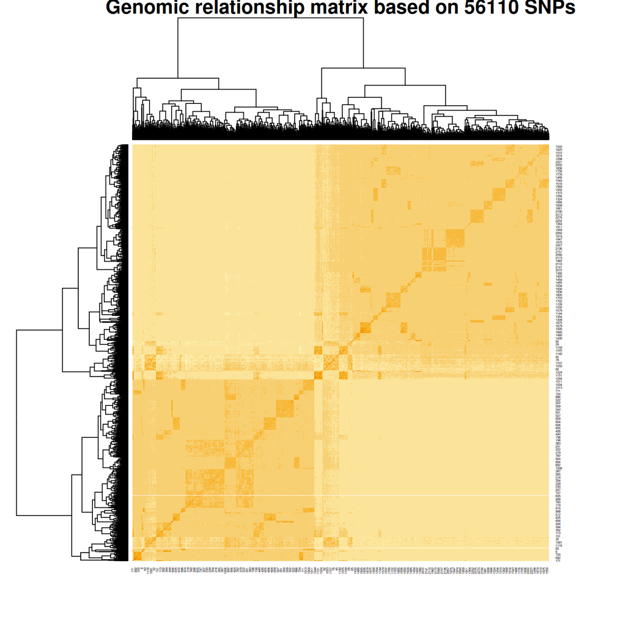

```r
heatmap(
  dados.Gmatrix,
  main = paste(
    "Genomic relationship matrix based on",
    ncol(dado_matrix), "SNPs"
  ),
  cexRow = 0.3,
  cexCol = 0.3
)
```

```r
library(RColorBrewer)
library(dendextend)
library(magrittr)

k <- 7 # número de grupos
D <- dist(dados.Gmatrix)
hc <- hclust(D)

dend <- hc %>%
  as.dendrogram() %>%
  color_branches(k = k, groupLabels = c(1:k), col = c(brewer.pal('Set1', n = 8))[-6]) %>%
  dendextend::set("labels_cex", 0.3) # Força o uso da função do dendextend
```

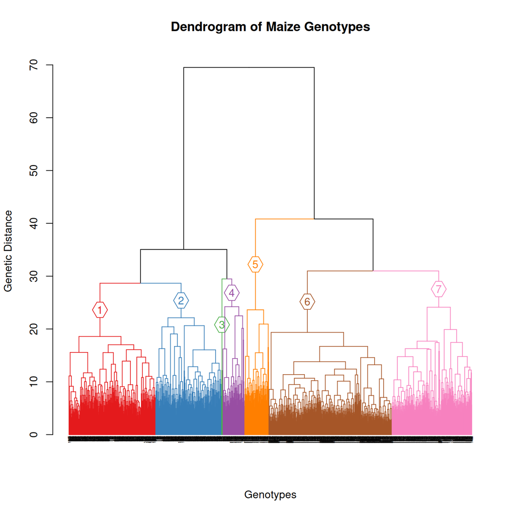

```r
plot(
  dend,
  main = "Dendrogram of Maize Genotypes",
  ylab = "Genetic Distance",
  xlab = "Genotypes"
)
```

A hierarchical clustering dendrogram based on Euclidean distance derived from marker/genomic data, segmented into 7 distinct clusters (labeled 1 through 7) defined based on ($\mathbf{G}$ matrix). Clusters 1 (red), 2 (blue), 6 (brown), and 7 (pink) represent larger sub-populations. Clusters 3 (green), 4 (purple), and 5 (orange) form smaller, more specialized lineages or intermediate sub-groups.

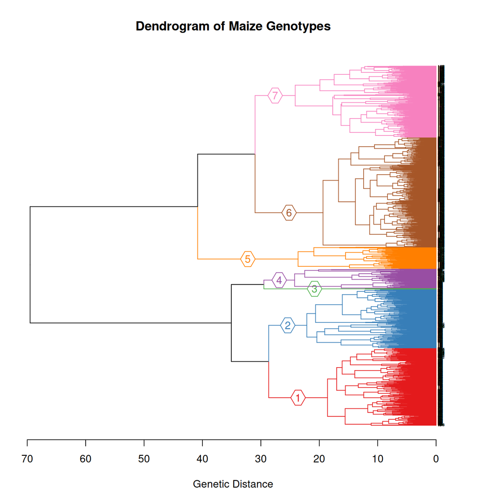

```r
par(mar = c(5.1, 1.1, 4.1, 4.1))

plot(
  dend,
  horiz = TRUE,
  main = "Dendrogram of Maize Genotypes",
  xlab = "Genetic Distance"
)
```

Horizontal dendogram showing the same relationship pattern as the dendogram before in vertical.

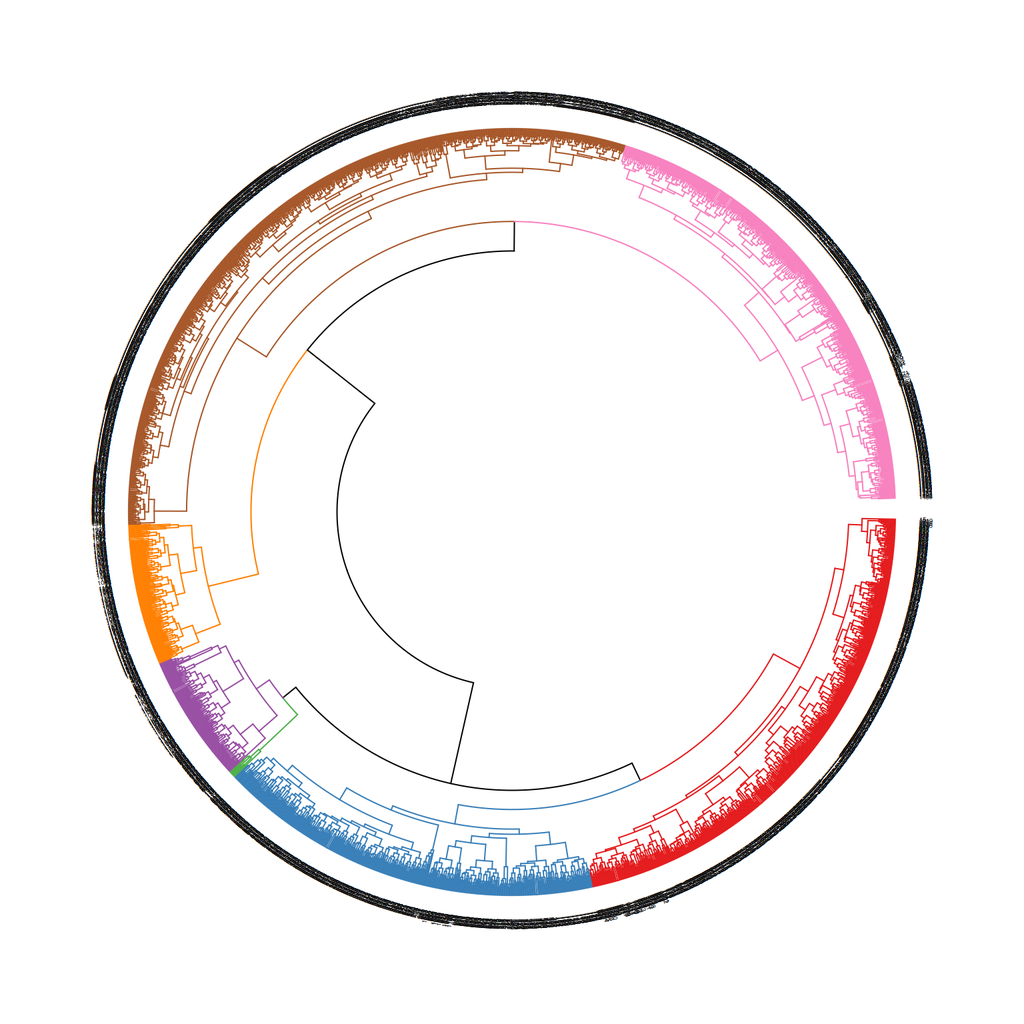

```r
circlize_dendrogram(dend)
```

A circular representation of the 7-cluster hierarchical tree. Arranges leaf nodes (genotypes) around a circular perimeter with radial branch lengths representing genetic distances. Highlighting with cluster colors demonstrates clear partitioning of the circumference into the 7 defined genetic groups.

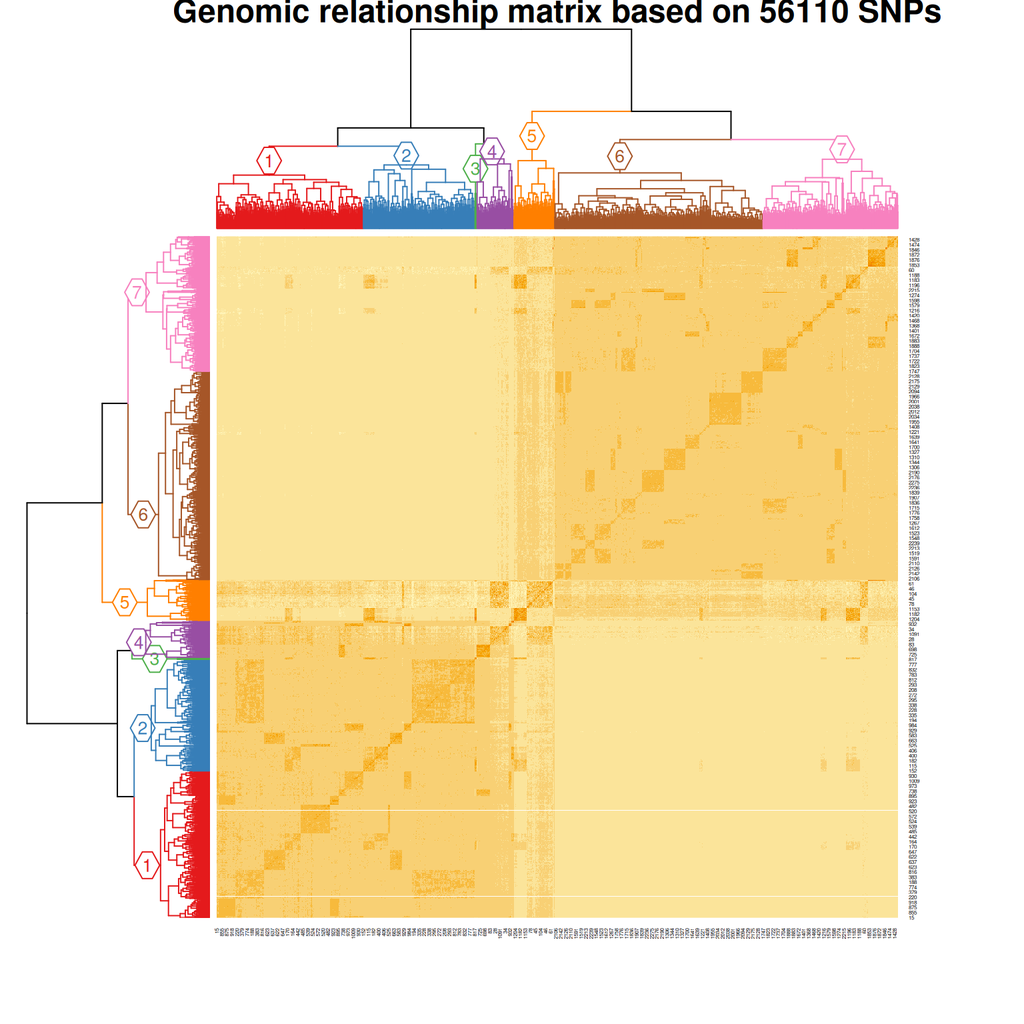

```r
heatmap(dados.Gmatrix, cexRow = .3, cexCol = .3, Rowv = dend, Colv = dend, main = paste("Genomic relationship matrix based on", ncol(dado_matrix), "SNPs"))
```

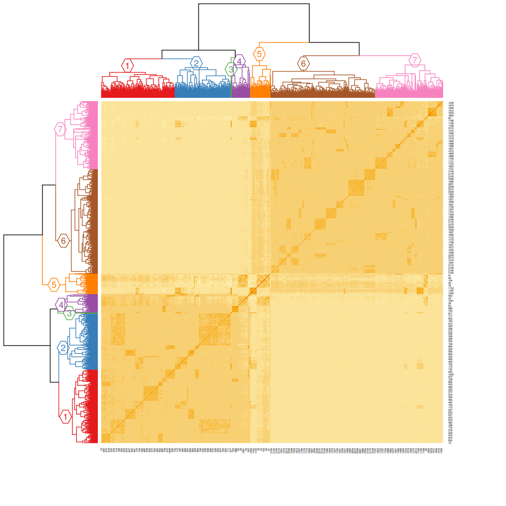

```r
heatmap(dados.Gmatrix, cexRow = .3, cexCol = .3, Rowv = dend, Colv = dend, margins = c(6,6))
```

The same ($\mathbf{G}$ matrix) as before with no title to allow better visualization.

```r
library(dendextend)


dend <- as.dendrogram(hc)


grupos_ordenados <- grupo[match(labels(dend), rownames(dados_num))]



cores_grupo <- c("Pais" = "#e41a1c", "Dent" = "#377eb8", "Flint" = "#4daf4a")
colunas_cores <- cores_grupo[as.character(grupos_ordenados)]


labels_colors(dend) <- colunas_cores
```

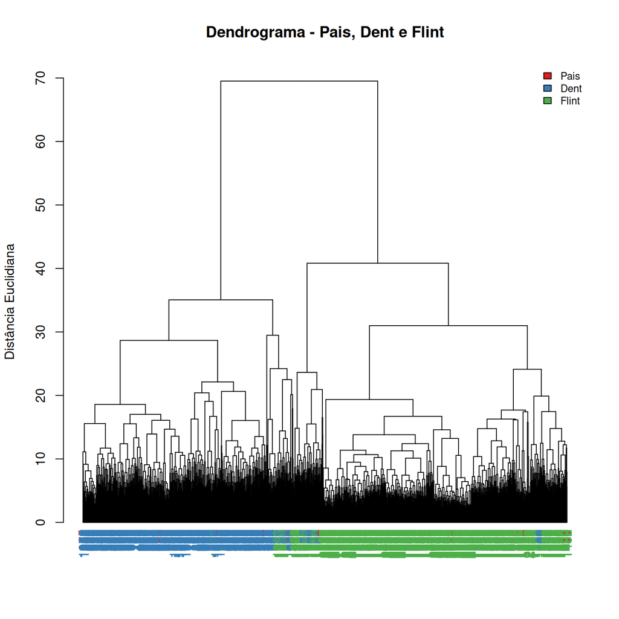

```r
plot(dend,
     main = "Dendrograma - Pais, Dent e Flint",
     ylab = "Distância Euclidiana",
     cex = 0.4) # Ajuste o tamanho da fonte se necessário
legend("topright",
       legend = names(cores_grupo),
       fill = cores_grupo,
       bty = "n",
       cex = 0.8)
```

A hierarchical dendrogram with Euclidean distance on the $y$-axis, where leaf labels are color-coded by pre-defined germplasm classes: Pais (Parents - red), Dent (blue), and Flint (green). Shows strong alignment between genomic distance clustering and the classic Dent vs. Flint heterotic pattern. Dent and Flint genotypes form two primary overarching branches, while parental lines (“Pais”) are interspersed within their respective heterotic backgrounds.

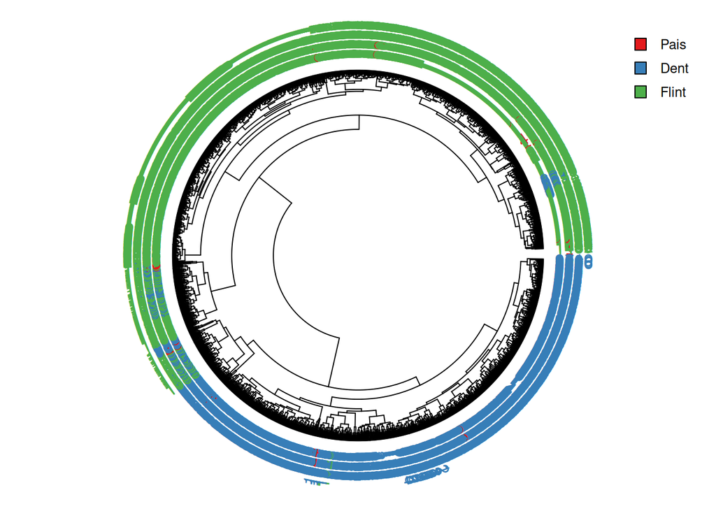

```r
circlize_dendrogram(dend)
legend("topright",
       legend = names(cores_grupo),
       fill = cores_grupo,
       bty = "n",
       cex = 0.8)
```

A circular polar dendrogram displaying the distribution of Pais, Dent, and Flint genotypes along the outer ring.Highlights clear structural separation into two major hemispheres corresponding to the Flint (green) and Dent (blue) heterotic groups.Parental lines (red markers) are strategically located at specific sub-clades within both major groups.

Elaborating PCAs

```r
library(pcaMethods)
library(dplyr)
nPcs <- 10
dado_matrix <- dado_matrix[, colSums(is.na(dado_matrix)) < nrow(dado_matrix)]
pcas <- pca(dado_matrix, method = "svd", scale = "none", nPcs = nPcs)
head(pcas@scores[,c(1,2)])
```

```
##            PC1          PC2
## [1,] -46.03985 -196.2917962
## [2,] -60.76826   -8.9771057
## [3,] -67.23549   -0.1836876
## [4,]  42.36451    8.0932188
## [5,]  43.65162    1.6478055
## [6,] -37.40932  -91.5821082
```

```r
library(dplyr)
scores <- data.frame(pcas@scores)
scores$ID <- rownames(dados)
head(scores)
```

```
##         PC1          PC2         PC3        PC4         PC5         PC6
## 1 -46.03985 -196.2917962   -4.438539  -4.201587  -3.6804521 -20.8783406
## 2 -60.76826   -8.9771057 -144.951034 -10.503578   0.9078278   8.9697318
## 3 -67.23549   -0.1836876 -131.937569  -7.075265   6.8868356  -0.4327193
## 4  42.36451    8.0932188  -15.072967   2.282102 -28.5909548   9.8022380
## 5  43.65162    1.6478055   -5.881847 -31.361990 -64.4959809  -5.9771661
## 6 -37.40932  -91.5821082  -29.041825 -20.710427 -12.4248353   0.8104259
##          PC7        PC8        PC9        PC10          ID
## 1 -21.531150 -11.772462   9.963500   0.3987793   B73.GType
## 2 -13.343663   9.988848  15.872984   4.0254998   D06.GType
## 3  -1.101992   5.829788  18.251013   8.0148740   D09.GType
## 4 -32.085643 -48.470626   3.676458 110.3012204  D152.GType
## 5 -12.498695 -10.816055   7.793731  37.0142790 DK105.GType
## 6 -29.519554  14.002168 -31.568413   9.2781322 EC169.GType
```

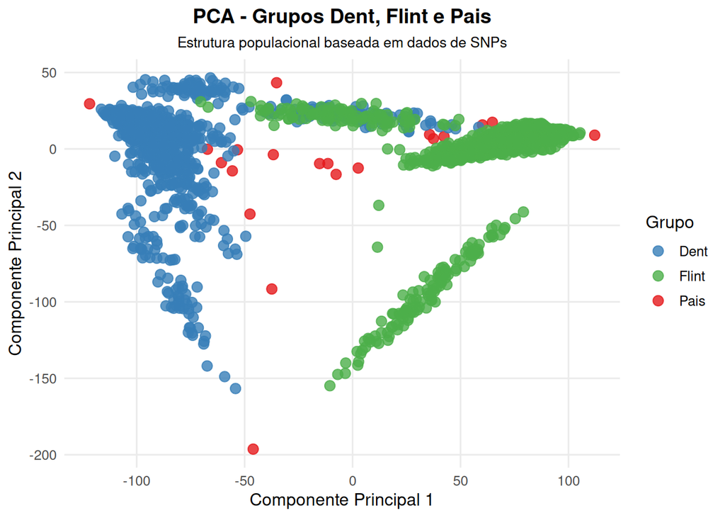

```r
dados_com_id <- dados
dados_com_id$ID <- rownames(dados_com_id)

scores <- scores %>%
  dplyr::select(-any_of(c("Address", "Grupo"))) %>%
  left_join(dados_com_id %>% dplyr::select(ID, Grupo), by = "ID") %>%
  mutate(Grupo = as.factor(Grupo))


ggplot(scores, aes(x = PC1, y = PC2, color = Grupo)) +
  geom_point(size = 3, alpha = 0.8) +
  theme_minimal(base_size = 12) +
  labs(
    title = "PCA - Grupos Dent, Flint e Pais",
    subtitle = "Estrutura populacional baseada em dados de SNPs",
    x = "Componente Principal 1",
    y = "Componente Principal 2"
  ) +
  scale_color_manual(values = c("Pais" = "#e41a1c", "Dent" = "#377eb8", "Flint" = "#4daf4a")) +
  theme(
    plot.title = element_text(face = "bold", size = 14, hjust = 0.5),
    plot.subtitle = element_text(size = 10, hjust = 0.5),
    legend.position = "right",
    panel.grid.minor = element_blank()
  )
```

```r
ggsave("PCA_maize.png", height = 5, width = 7, dpi = 500)
dev.off()
## null device
##           1
```

The scatter plot illustrates the population structure of a maize collection based on SNP data, mapping individuals across Principal Component 1 (PC1) and Principal Component 2 (PC2). PC1 effectively separates the major genetic pools, clustering the Dent genotypes predominantly on the negative side of the axis and the Flint genotypes on the positive side. This reflects the classic genetic divergence between North American Dent and European/tropical Flint heterotic groups. The parental genotypes (red dots) are scattered across various regions of the plot, bridging the space between and within the major heterotic clusters. This dispersion indicates that the parents originate from diverse genetic backgrounds, encompassing both pure pool lines and inter-pool crosses.

3D PCA:

```r
library(plotly)
library(dplyr)

# 1. Limpar o data.frame removendo qualquer linha com NA nas coordenadas ou no Grupo
scores_limpo <- scores %>%
  filter(!is.na(PC1) & !is.na(PC2) & !is.na(PC3) & !is.na(Grupo))

# 2. Filtrar os indivíduos específicos que você quer destacar no gráfico (ex: Irene, UFLA R1440, Ligeirinha)
scores_par <- scores_limpo %>%
  filter(ID %in% c("Irene", "UFLA R1440", "Ligeirinha"))

# 3. Criar o gráfico 3D interativo com o plotly
p <- plot_ly() %>%
  # Adicionar os pontos principais coloridos por Grupo
  add_trace(
    data = scores_limpo,
    x = ~PC1, y = ~PC2, z = ~PC3,
    color = ~Grupo,
    colors = c("Pais" = "#e41a1c", "Dent" = "#377eb8", "Flint" = "#4daf4a"), # Cores customizadas
    type = 'scatter3d',
    mode = 'markers',
    marker = list(size = 4, opacity = 0.8),
    text = ~ID, # Mostra o ID ao passar o mouse
    hoverinfo = 'text'
  ) %>%
  # Adicionar os rótulos de texto para os parentais/indivíduos de interesse
  add_text(
    data = scores_par,
    x = ~PC1, y = ~PC2, z = ~PC3,
    text = ~ID,
    textposition = "top right",
    showlegend = FALSE,
    textfont = list(color = 'black', size = 12)
  ) %>%
  # Configurar os eixos e títulos (incluindo a porcentagem de variância explicada da PCA)
  layout(
    title = "PCA 3D - Grupos Dent, Flint e Pais",
    scene = list(
      xaxis = list(title = paste0("PC1 (", sprintf(pcas@R2[1]*100, fmt = '%#.2f'), "%)")),
      yaxis = list(title = paste0("PC2 (", sprintf(pcas@R2[2]*100, fmt = '%#.2f'), "%)")),
      zaxis = list(title = paste0("PC3 (", sprintf(pcas@R2[3]*100, fmt = '%#.2f'), "%)"))
    )
  )

# Exibir o gráfico interativo na aba "Viewer" do RStudio
p
```

[interactive chart not shown]

```r
# 4. (Opcional) Se quiser salvar o gráfico interativo em um arquivo HTML para abrir no navegador:
 htmlwidgets::saveWidget(p, "PCA_maize_3d.html")
```

The 3D PCA confirms results of 2D PCA and allows for better visualization of the two major heterotic groups and the in between parental group.